# Heart_Failure_Prediction_Final

## 2.2 Visualizando Multicolinearidade

```python
def scatter_plot_conjunto(data, columns, target):
    # Definindo range de Y
    y_range = [data[target].min(), data[target].max()]

    for column in columns:
        if target != column:
            # Definindo range de X
            x_range = [data[column].min(), data[column].max()]

            # Scatter plot de X e Y
            scatter_plot = data.plot(kind = 'scatter', x = column, y = target, xlim = x_range, ylim = y_range)

            # Traçar linha da media de X e Y
            meanX = scatter_plot.plot(x_range, [data[target].mean(), data[target].mean()], '--', color = 'red', linewidth = 1)
            meanY = scatter_plot.plot([data[column].mean(), data[column].mean()], y_range, '--', color = 'red', linewidth = 1)
```

```python
heart_multicolinearidade = heart[['age', 'creatinine_phosphokinase' ,'ejection_fraction', 'serum_creatinine', 'serum_sodium']]
```

Analisando os scatterplots abaixos não é notavel uma grande correlação entre as variaveis indicadas, sendo assim não podendo determinar de imediato a existencia de multicolinearidade.

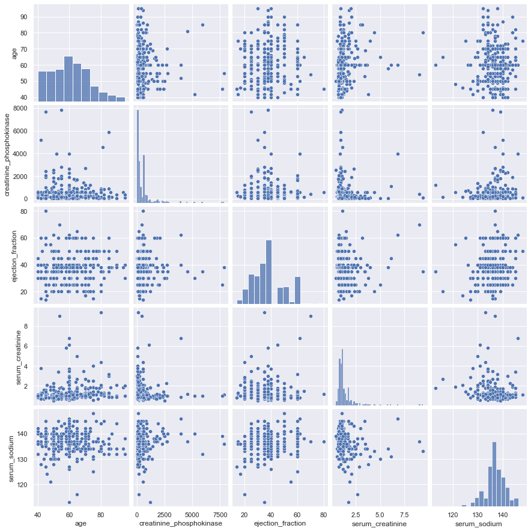

```python
sns.pairplot(heart_multicolinearidade)
```

Algumas analises sobre cada variavel continua em relação com a variavel target.

Age: O seu valor tende a ser maior na classe 1, representado pela média e pelos quartis inferiores/superiores. Esse valor já era esperado devido ao aumento da vulnerabilidade na classe idosa.

Ejection_Fraction: O seu valor tende a ser menor na classe, representando um cenário onde pessoas que morrem por doenças cardiovasculares tem uma menor taxa de sangue saindo do corpo.

Serum_creatine: É visto que claramente o seu aumento no sangue leva a maiores taxas de falha cardiovascular. Esse é um fato que gera muita controversia apesar de já terem estudos que comprovem o fato, agora temos dados.

Serum_sodium: Conforme o seu valor desce maior a taxa de falha cardiovascular por doença cardiovascular. É perceptivel que apartir de valores menores que 135mEq/L a taxa da classe 1 aumenta muito, isso se da principalmente pela Hiponatremia.

Time: Claramente de acordo com o seu declineo possui um aumento avassalador na classe 1. O que faz total sentido visto que pessoas que visitam o médico mais tarde quando a doença já possui uma maior gravidade, tem menos tempo de reagir a um tratamento.

```python
def boxplot_plot_individual(data, columns, target):

    fig = plt.figure()
    fig.subplots_adjust(hspace = 0.4, wspace = 0.4)
    fig.set_figheight(25)
    fig.set_figwidth(15)

    columns_adjust = ceil(len(columns))

    for i, column in enumerate(columns):
        if column != target:
            ax = fig.add_subplot(columns_adjust, 3, i + 1)
            sns.boxplot(x = target, y = column, data = data)

    plt.tight_layout()
    plt.show()
```

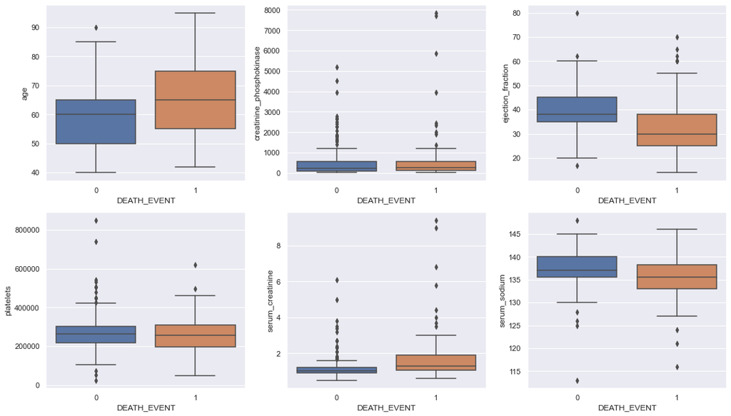

```python
boxplot_plot_individual(heart, continuas, 'DEATH_EVENT')
```

Por ulitmo, é interessante analisar o scatterplot de todas variaveis continuas e não somente as que possuem multicolinearidade. Assim conseguimos ter um overview de nossas variaveis.

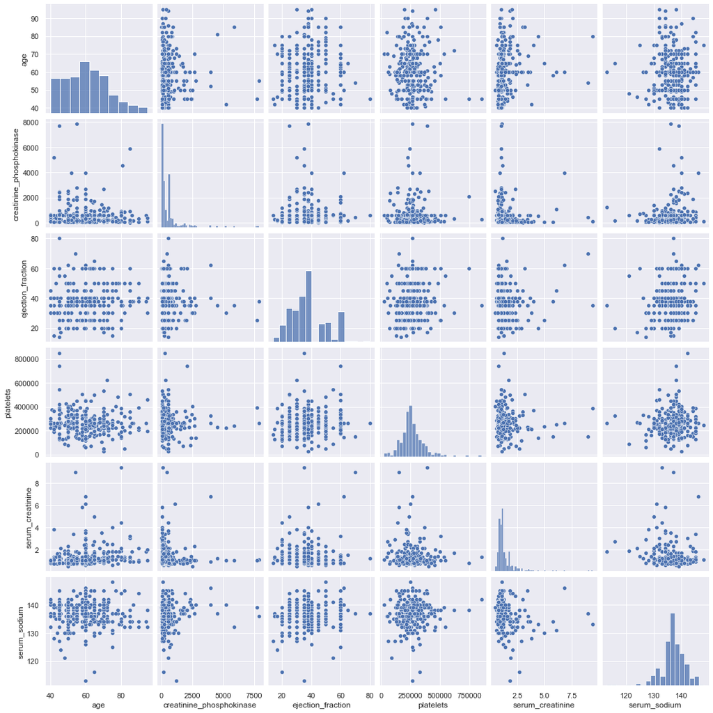

```python
sns.pairplot(heart[continuas])
```

# 3. Pre-Processamento

## 3.1 Detectando Outliers

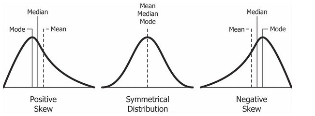

```python
print(heart[continuas].skew())
```

```
age                         0.423062
creatinine_phosphokinase    4.463110
ejection_fraction           0.555383
platelets                   1.462321
serum_creatinine            4.455996
serum_sodium               -1.048136
dtype: float64
```

```python
def hist_individual(data, columns):
    fig = plt.figure()
    fig.subplots_adjust(hspace = 0.4, wspace = 0.4)
    fig.set_figheight(10)
    fig.set_figwidth(15)

    columns_adjust = ceil(len(columns) / 3)

    for i, column in enumerate(columns):
        ax = fig.add_subplot(columns_adjust, 3, i + 1)
        data[column].hist(label = column)
        plt.title(column)

    plt.tight_layout()
    plt.show()
```

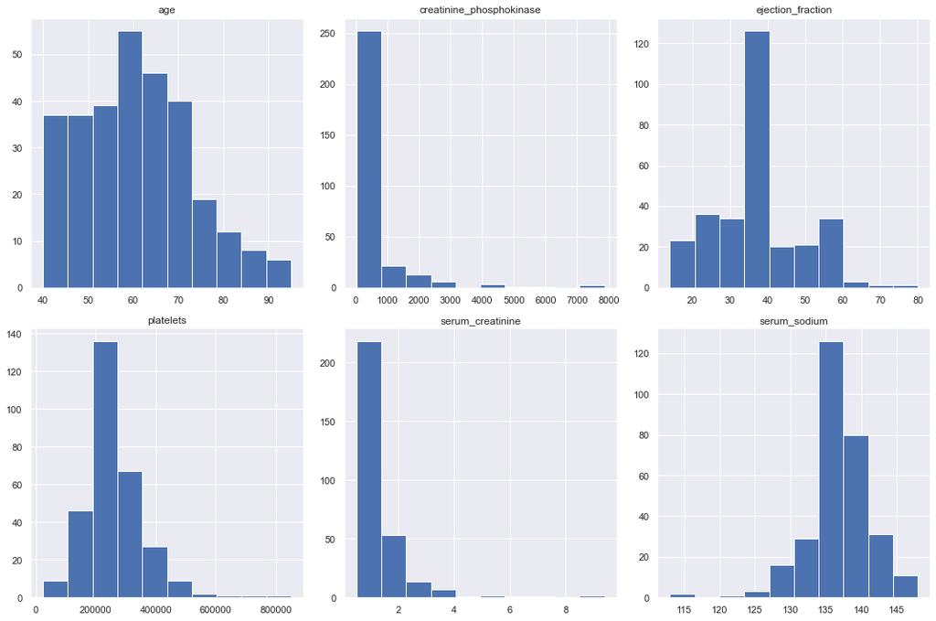

```python
hist_individual(heart, continuas)
```

Uma das estatisticas que pode ser de grande importância para a detecção de outliers é Exceço de Kurtosis, onde podemos entender facilmente as variaveis que possuem muitos valores distuantes (outliers). Onde a sua formula é constituiada em:

#### Exceço de Kurtosis = Kurtosis - 3

Mesokurtic -> Exceço de Kurtosis ~= 0: Outliers proximo a distribuição normal.

```python
print(heart[continuas].kurtosis() - 3)
```

```
age                         -3.184871
creatinine_phosphokinase    22.149046
ejection_fraction           -2.958591
platelets                    3.209255
serum_creatinine            22.828239
serum_sodium                 1.119712
dtype: float64
```

Para um melhor entendimento sobre os numeros oferecidos pela metrica de Exceço de Kurtosis, iremos trazer o boxplot de cada uma dessas variaveis. É perceptivel que nas variaveis 'age' e 'ejection_fraction', por possuirem uma kurtosis muito negativa os seus outliers são quase que imperceptiveis, visto que não trazem peso para o problema. Porém a variavel 'creatinine_phosphokinase', 'platelets' e 'serum_creatinine' possuem muitos outliers, trazendo grande peso ao boxplot.

```python
def boxplot_individuais(data, columns):
    fig = plt.figure()
    fig.subplots_adjust(hspace = 0.4, wspace = 0.4)
    fig.set_figheight(8)
    fig.set_figwidth(15)

    columns_adjust = ceil(len(columns) / 3)

    for i, column in enumerate(columns):
        ax = fig.add_subplot(columns_adjust, 3, i + 1)
        sns.boxplot(x = data[column])

    plt.tight_layout()
    plt.show()
```

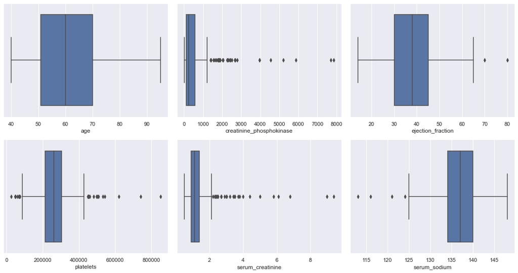

```python
boxplot_individuais(heart, continuas)
```

## 3.2 Removendo Outliers

```python
# Criando array de colunas com outliers
outlier_columns = continuas.copy()
outlier_columns.remove('age')
print(outlier_columns)
```

```
['creatinine_phosphokinase', 'ejection_fraction', 'platelets', 'serum_creatinine', 'serum_sodium']
```

```python
def outlier_log_transformation_based(data, columns):
    for column in columns:
        data[column] = data[column].map(lambda x: np.log(x) if x > 0 else 0)
    return data
```

```python
def outlier_percentil_based(data, columns):
    for column in columns:
        # Capturando percentile de 10 e 90
        percentil10 = data[column].quantile(0.10)
        percentil90 = data[column].quantile(0.90)

        data[column] = np.where(data[column] < percentil10, percentil10, data[column])
        data[column] = np.where(data[column] > percentil90, percentil90, data[column])

    return data
```

```python
heart = outlier_percentil_based(heart, outlier_columns)
```

Analisando novamente o Skew e o histograma, é perceptivel que os dados perderam um pouco do seu formato.

```python
print(heart[continuas].skew())
```

```
age                         0.423062
creatinine_phosphokinase    0.987717
ejection_fraction           0.663999
platelets                   0.183135
serum_creatinine            0.969494
serum_sodium               -0.103250
dtype: float64
```

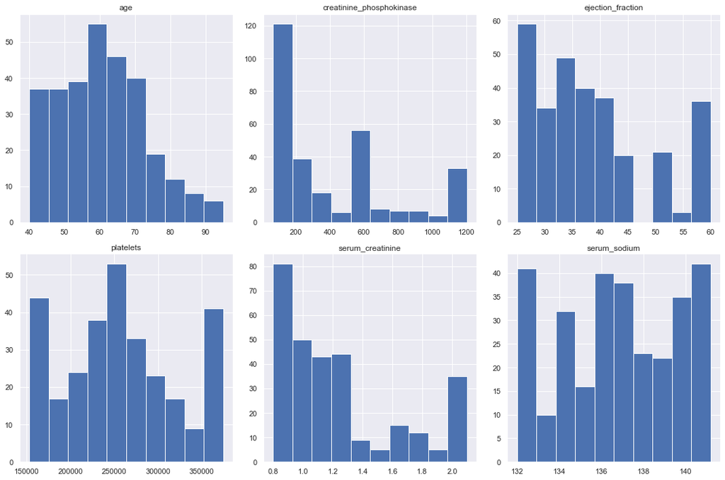

```python
hist_individual(heart, continuas)
```

Já analisando a Kurtosis é perceptivel que os dados tiveram os seus outliers ajustados, passando a não exibirem valores extremos com frequência.

```python
print(heart[continuas].kurtosis() - 3)
```

```
age                        -3.184871
creatinine_phosphokinase   -3.206519
ejection_fraction          -3.409022
platelets                  -3.827136
serum_creatinine           -3.309419
serum_sodium               -4.161165
dtype: float64
```

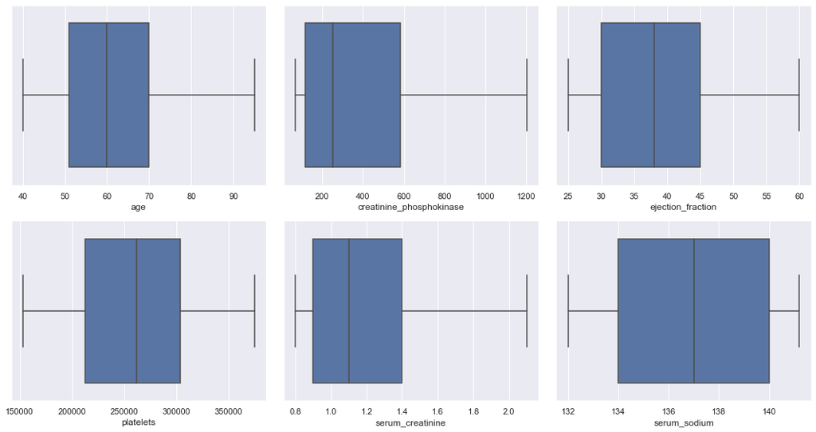

```python
boxplot_individuais(heart, continuas)
```

## 3.3 Padronização dos Dados

Para os algoritmos que iremos aplicar como K-means e SVM o ideal é utilizar a Padronização ao invés da Normalização.

```python
X = heart.iloc[:, :-1]
y = heart['DEATH_EVENT'].values
```

```python
X.head()
```

|  | age | anaemia | creatinine_phosphokinase | diabetes | ejection_fraction | high_blood_pressure | platelets | serum_creatinine | serum_sodium | sex | smoking |
| --- | --- | --- | --- | --- | --- | --- | --- | --- | --- | --- | --- |
| 0 | 75.0 | 0 | 582.0 | 0 | 25.0 | 1 | 265000.00 | 1.9 | 132.0 | 1 | 0 |
| 1 | 55.0 | 0 | 1203.8 | 0 | 38.0 | 0 | 263358.03 | 1.1 | 136.0 | 1 | 0 |
| 2 | 65.0 | 0 | 146.0 | 0 | 25.0 | 0 | 162000.00 | 1.3 | 132.0 | 1 | 1 |
| 3 | 50.0 | 1 | 111.0 | 0 | 25.0 | 0 | 210000.00 | 1.9 | 137.0 | 1 | 0 |
| 4 | 65.0 | 1 | 160.0 | 1 | 25.0 | 0 | 327000.00 | 2.1 | 132.0 | 0 | 0 |

```python
print(y)
```

```
[1 1 1 1 1 1 1 1 1 1 1 1 1 1 0 1 1 1 1 1 0 1 1 0 1 1 1 1 1 1 1 1 1 0 1 1 1
 1 0 1 1 1 1 0 1 1 1 1 1 1 1 1 1 1 1 1 0 0 1 1 1 1 0 1 0 1 1 1 1 1 0 0 1 0
 1 1 0 0 0 0 0 0 1 0 1 0 0 0 0 0 0 0 0 1 0 0 0 0 0 0 0 0 0 0 0 1 0 0 0 0 1
 0 0 1 0 0 0 0 0 1 0 0 0 0 1 0 1 0 0 0 0 0 0 0 0 0 0 0 0 0 1 0 0 0 1 0 0 0
 1 0 1 0 0 0 0 0 0 0 0 0 0 0 0 1 1 1 0 1 0 0 0 0 0 0 0 0 0 0 0 0 0 1 1 1 1
 1 1 1 0 0 0 0 0 0 1 1 0 0 0 0 0 0 0 0 0 0 0 0 0 0 0 0 0 1 0 0 0 1 0 0 1 0
 0 0 0 0 0 0 0 0 1 0 0 0 0 0 0 0 0 0 0 0 0 0 0 0 1 0 0 0 0 0 0 0 0 0 0 0 0
 0 0 0 1 0 0 0 1 0 0 0 0 0 0 0 0 0 0 0 0 0 0 0 0 0 0 0 0 0 0 0 0 0 0 0 0 0
 0 0 0]
```

```python
# Aplicando padronização
scaler = StandardScaler()
X_standard = scaler.fit_transform(X)
```

```python
print(X_standard)
```

```
[[ 1.19294523 -0.87110478  0.44656511 ... -1.58662083  0.73568819
  -0.68768191]
 [-0.49127928 -0.87110478  2.13856173 ... -0.25777033  0.73568819
  -0.68768191]
 [ 0.35083298 -0.87110478 -0.73984615 ... -1.58662083  0.73568819
   1.4541607 ]
 ...
 [-1.33339153 -0.87110478  2.13856173 ...  0.40665492 -1.35927151
  -0.68768191]
 [-1.33339153 -0.87110478  2.13856173 ...  1.07108017  0.73568819
   1.4541607 ]
 [-0.9123354  -0.87110478 -0.60378982 ... -0.25777033  0.73568819
   1.4541607 ]]
```

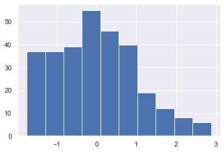

```python
plt.hist(X_standard[:,0:1])
```

# 4. Balanceando os Dados

É demonstrado abaixo que os dados estão desbalanceados, com aproximadamente dois terços da base sendo da classe 0. Assim o nosso modelo irá se tornar tendencioso, iremos tentar utilizar tecnicas de balanceamento como SMOTE para melhorar os resultados.

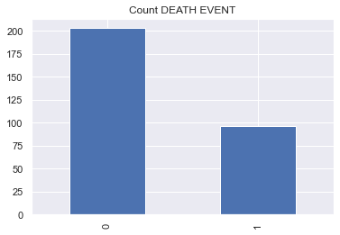

```python
heart_original.DEATH_EVENT.value_counts().plot(kind = 'bar', title = 'Count DEATH EVENT')
```

```python
x_train, x_test, y_train, y_test = train_test_split(X_standard, y, test_size = .3, random_state = seed_)
```

```python
oversample = SMOTE(random_state = seed_)
x_train_resample, y_train_resample = oversample.fit_resample(x_train, y_train)
```

```python
y_all = np.concatenate((y_train_resample, y_test), axis = 0)
```

```python
print(np.shape(y_test),
np.shape(y_train_resample),
np.shape(y_all))
```

```
(90,) (284,) (374,)
```

```python
Counter(y_all)
```

```
Counter({1: 171, 0: 203})
```

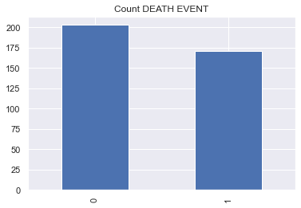

```python
dt = pd.DataFrame(y_all, columns = ['target'])
dt.target.value_counts().plot(kind ='bar', title = 'Count DEATH EVENT')
```

# 5. Feature Selecting

Para aumentar a generalização do nosso modelo, evitando futuro overfitting, podemos aplicar de técnicas de Feature Selecting para a redução de algumas variaveis. Antes é importante ressaltar quais insights já foram dados ao longo da analise exploratória.

1 - A variavel 'times' já foi removida do dataset e não será utilizada visto que possui ligação direta com a variavel target, sendo uma variavel coletada somente após o evento acontecer.

2 - Age: O seu valor tende a ser maior na classe 1, representado pela média e pelos quartis inferiores/superiores. Esse valor já era esperado devido ao aumento da vulnerabilidade na classe idosa.

3 - Ejection_Fraction: O seu valor tende a ser menor na classe, representando um cenário onde pessoas que morrem por doenças cardiovasculares tem uma menor taxa de sangue saindo do corpo.

4 - Serum_creatine: É visto que claramente o seu aumento no sangue leva a maiores taxas de falha cardiovascular. Esse é um fato que gera muita controversia apesar de já terem estudos que comprovem o fato, agora temos dados.

5 - Serum_sodium: Conforme o seu valor desce maior a taxa de falha cardiovascular por doença. É perceptivel que apartir de valores menores que 135mEq/L a taxa da classe 1 aumenta muito, isso se da principalmente pela Hiponatremia.

## 5.1 XGBOOST

```python
modeloXGB = xgb.XGBClassifier(n_estimators = 1000, use_label_encoder = False, seed_ = seed_)
```

```python
modeloXGB.fit(X_standard, y)
```

[output not shown]

```
XGBClassifier(base_score=0.5, booster='gbtree', colsample_bylevel=1,
              colsample_bynode=1, colsample_bytree=1, gamma=0, gpu_id=-1,
              importance_type='gain', interaction_constraints='',
              learning_rate=0.300000012, max_delta_step=0, max_depth=6,
              min_child_weight=1, missing=nan, monotone_constraints='()',
              n_estimators=1000, n_jobs=24, num_parallel_tree=1, random_state=0,
              reg_alpha=0, reg_lambda=1, scale_pos_weight=1, seed_=194,
              subsample=1, tree_method='exact', use_label_encoder=False,
              validate_parameters=1, verbosity=None)
```

```python
print(modeloXGB.feature_importances_)
```

```
[0.08655462 0.02514137 0.0560401  0.02858021 0.17375933 0.0743641
 0.04546017 0.15915318 0.10861176 0.12236615 0.1199689 ]
```

```python
index_ordenado = modeloXGB.feature_importances_.argsort()
```

```python
index_ordenado
```

```
array([ 1,  3,  6,  2,  5,  0,  8, 10,  9,  7,  4], dtype=int64)
```

```
<BarContainer object of 11 artists>
```

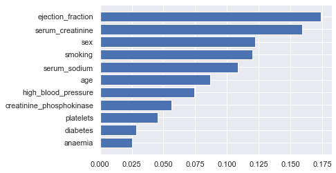

```python
plt.barh(heart.drop('DEATH_EVENT', axis = 1).columns[index_ordenado], modeloXGB.feature_importances_[index_ordenado])
```

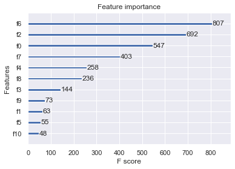

```python
plot_importance(modeloXGB)
```

## 5.2 RFE (Recursive Feature Elimination)

```python
modeloRFE = LogisticRegression(solver = 'lbfgs', random_state = seed_)
rfe = RFE(modeloRFE, n_features_to_select = 6)
fit = rfe.fit(X_standard, y)
```

```python
print("Features Selecionadas: %s" % fit.support_)
print("Feature Ranking: %s" % fit.ranking_)
```

```
Features Selecionadas: [ True  True False False  True  True False  True  True False False]
Feature Ranking: [1 1 2 6 1 1 5 1 1 3 4]
```

```python
selecionadas = [columns[i] for i, col in enumerate(fit.support_) if col == True]
```

```python
selecionadas
```

```
['age',
 'anaemia',
 'ejection_fraction',
 'high_blood_pressure',
 'serum_creatinine',
 'serum_sodium']
```

```python
heart[selecionadas].head()
```

|  | age | anaemia | ejection_fraction | high_blood_pressure | serum_creatinine | serum_sodium |
| --- | --- | --- | --- | --- | --- | --- |
| 0 | 75.0 | 0 | 25.0 | 1 | 1.9 | 132.0 |
| 1 | 55.0 | 0 | 38.0 | 0 | 1.1 | 136.0 |
| 2 | 65.0 | 0 | 25.0 | 0 | 1.3 | 132.0 |
| 3 | 50.0 | 1 | 25.0 | 0 | 1.9 | 137.0 |
| 4 | 65.0 | 1 | 25.0 | 0 | 2.1 | 132.0 |

## 5.3 Extra Trees Classifier

```python
modeloExtraTrees = ExtraTreesClassifier(n_estimators = 1000, random_state = seed_)
modeloExtraTrees.fit(X_standard, y)
print(modeloExtraTrees.feature_importances_)
```

```
[0.1322135  0.03761433 0.09971018 0.05015474 0.14472388 0.03769115
 0.10798292 0.18853182 0.11691522 0.0416596  0.04280264]
```

```python
index_ordenado_extra = modeloExtraTrees.feature_importances_.argsort()
```

```
<BarContainer object of 11 artists>
```

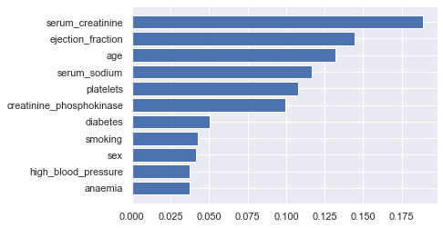

```python
plt.barh(heart.drop('DEATH_EVENT', axis = 1).columns[index_ordenado_extra],
         modeloExtraTrees.feature_importances_[index_ordenado_extra])
```

## 5.4 Aplicando Feature Selecting

```python
heart.head()
```

|  | age | anaemia | creatinine_phosphokinase | diabetes | ejection_fraction | high_blood_pressure | platelets | serum_creatinine | serum_sodium | sex | smoking | DEATH_EVENT |
| --- | --- | --- | --- | --- | --- | --- | --- | --- | --- | --- | --- | --- |
| 0 | 75.0 | 0 | 582.0 | 0 | 25.0 | 1 | 265000.00 | 1.9 | 132.0 | 1 | 0 | 1 |
| 1 | 55.0 | 0 | 1203.8 | 0 | 38.0 | 0 | 263358.03 | 1.1 | 136.0 | 1 | 0 | 1 |
| 2 | 65.0 | 0 | 146.0 | 0 | 25.0 | 0 | 162000.00 | 1.3 | 132.0 | 1 | 1 | 1 |
| 3 | 50.0 | 1 | 111.0 | 0 | 25.0 | 0 | 210000.00 | 1.9 | 137.0 | 1 | 0 | 1 |
| 4 | 65.0 | 1 | 160.0 | 1 | 25.0 | 0 | 327000.00 | 2.1 | 132.0 | 0 | 0 | 1 |

### 5.4.1 Feature Selecting Baseado em Arvore - Mantendo Multicolineares

```python
'''
index_ordenado_invertido = np.flip(index_ordenado)
print(index_ordenado_invertido)

heart = heart.iloc[:, index_ordenado_invertido[0:6]]
features = index_ordenado_invertido[0:6]

# Mantendo os 6 melhores de acordo com XGBOOST sem excluir variaveis MultiColineares
x_train = x_train[:, index_ordenado_invertido[0:6]]
x_test = x_test[:, index_ordenado_invertido[0:6]]
x_train_resample = x_train_resample[:, index_ordenado_invertido[0:6]]
'''
```

### 5.4.2 Feature Selecting Baseado em Arvore - Excluindo Multicolineares

```python
'''
Mantendo os 6 melhores de acordo com XGBOOST excluindo as MultiColinearidades

Variaveis com multicolinearidade:
age, creatinine_phosphokinase, ejection_fraction, serum_creatinine e serum_sodium
'''
'''
features = [0, 2, 3, 5, 6, 8]

heart = heart.iloc[:, features]

x_train = x_train[:, features]
x_test = x_test[:, features]
x_train_resample = x_train_resample[:, features]
'''
```

### 5.4.3 Feature Selecting Baseado no Cox Proportional Hazard - Mantendo Multicolineares

```python
'''
Mantendo as variaveis indicadas confiaveis e ideais pelo Cox Proportional Hazard,
sem adaptar o modelo para remover multicolineres.
'''

features = [5, 1, 7, 3, 10, 0]

heart = heart.iloc[:, features]

x_train = x_train[:, features]
x_test = x_test[:, features]
x_train_resample = x_train_resample[:, features]
```

## 5.5 Visualizando Resultado do Feature Selecting

```python
heart.head()
```

|  | high_blood_pressure | anaemia | serum_creatinine | diabetes | smoking | age |
| --- | --- | --- | --- | --- | --- | --- |
| 0 | 1 | 0 | 1.9 | 0 | 0 | 75.0 |
| 1 | 0 | 0 | 1.1 | 0 | 0 | 55.0 |
| 2 | 0 | 0 | 1.3 | 0 | 1 | 65.0 |
| 3 | 0 | 1 | 1.9 | 0 | 0 | 50.0 |
| 4 | 0 | 1 | 2.1 | 1 | 0 | 65.0 |

```python
print(x_train[0])
```

```
[-0.73568819 -0.87110478 -0.33527655  1.1798305  -0.68768191 -1.33339153]
```

# 6. Modelagem Preditiva

Iniciando o ciclo de modelagem preditiva o nosso objetivo é treinar dois modelos, o primeiro modelo será o K-Means e após o SVM, primeiramente iremos utilizar o K-means para entender se o nosso modelo consegue separar as classes da forma correta, dessa forma iremos ter um melhor overview para treinar um modelo mais complexo como SVM.

```python
def report_modelo(modelo, y, pred, label = 'Modelo', save = False, target_names = [0, 1], cut_limit = 0.5):
    # Forçando predições para um numero inteiro
    pred[pred > cut_limit] = 1
    pred[pred <= cut_limit] = 0

    # Plotando a matriz de confusão
    cm = confusion_matrix(y, pred)
    cm = pd.DataFrame(cm, index = target_names, columns= target_names)

    plt.figure(figsize = (10, 10))
    sns.heatmap(cm, cmap = "Blues", linecolor = 'black', linewidths = 1, annot = True, \
                fmt = '', xticklabels = target_names, yticklabels = target_names)
    plt.show()

    print('AUC: %f' % roc_auc_score(y, pred))

    # Area sob  a curva ROC
    rfp, rvp, lim = roc_curve(y,  pred)

    plt.plot(rfp, rvp, marker = '.',  label = label,  color = 'orange')
    plt.plot([0, 1],  [0, 1], color = 'darkblue', linestyle = '--')
    plt.xlabel('Especificade')
    plt.ylabel('Sensibilidade')
    plt.legend()
    plt.show()

    # Acurácia
    print("Acurácia: %f" % accuracy_score(y, pred))

    # Classification Report
    print(classification_report(y, pred, target_names= target_names))

    # Salvando modelo sem sobreescrever arquivos existentes
    if save:
        shortFileName = '000'
        fileName = 'models/0001.model'
        fileObj = Path(fileName)

        index = 1
        while fileObj.exists():
            index += 1
            fileName = 'models/' + shortFileName + str(index) + '.model'
            fileObj = Path(fileName)

        # salvar modelo
        pickle.dump(modelo, open(fileName, 'wb'))

        return fileName
```

## 6.1 K-Means

Para o modelo K-means onde o K seria o numero de classe, não iremos realizar nenhum estudo sobre o numero de classes pois já sabemos com absoluta certeza quantas classe possuimos. Para esse problema, possuimos 2 classe, 0 ou 1, mais especificamente Morto ou Vivo. O unico objetivo com esse modelo é saber se os nossos dados possuem uma boa representatividade para algoritmos de Machine Learning.

Uma métrica que iremos utilizar será 'Hopkins' que irá nos dizer se os nossos dados são clusterizaveis.

Valores > .5 significam que o dataset não é "clusterizável"

Valores < .5 significam que o dataset é "clusterizável"

Quanto mais próximo de zero melhor.

```python
# Hopkins sem padronização
print("Sem padronização:", hopkins(X, X.shape[0]))

# Hopkins com padronização
print("Com padronização:", hopkins(X_standard, X_standard.shape[0]))

# Hopkins com padronização e feature selecting
X_standard_feature = X_standard[:, features]
print("Com padronização e feature selecting:", hopkins(X_standard_feature, X_standard_feature.shape[0]))

# Hopkins com normalização
scaler = MinMaxScaler()
X_scaled = scaler.fit_transform(X)
print("Com normalização:", hopkins(X_scaled, X_scaled.shape[0]))

# Hopkins com normalização e feature selecting
X_scaled_feature = X_scaled[:, features]
print("Com normalização e feature selecting:", hopkins(X_scaled_feature, X_scaled_feature.shape[0]))
```

```
Sem padronização: 0.3340137306047875
Com padronização: 0.43187955908551884
Com padronização e feature selecting: 0.22796747461813505
Com normalização: 0.37348931652691125
Com normalização e feature selecting: 0.1471515986471602
```

É perceptivel que os dados com normalização e feature selecting são os que possuem melhores resultado. Isso se da pois algoritmos como K-Means tendem a ter melhores resultados bons com normalização, baseando se na distância. Assim a normalização ficou com 0.14 e a padronização 0.22.

```python
print(x_train.shape, x_test.shape)
```

```
(209, 6) (90, 6)
```

```python
x_full = np.concatenate([x_train, x_test])
```

```python
print(x_full.shape)
```

```
(299, 6)
```

```python
# Aplicando a redução de dimensionalidade
pca = PCA(n_components = 2)
pca = pca.fit_transform(x_full)
```

Para o primeiro modelo iremos utilizar as variaveis de x sem o balanceamento nos dados, pois esse fator não deve ter um grande impacto, visto que precisamos separar os clusters e não os classificar.

```python
modelo_v1 = KMeans(n_clusters = 2, random_state = seed_)
modelo_v1.fit(pca)
```

```
KMeans(n_clusters=2, random_state=194)
```

```python
x_min, x_max, y_min, y_max, xx, yy, Z = [0, 0, 0, 0, 0, 0, 0]
```

```python
def minMax(pca_, modelo):
    global x_min, x_max, y_min, y_max, xx, yy, Z

    # Obtenção de valores minimos e maximos
    x_min, x_max = pca_[:, 0].min(), pca_[:, 0].max()
    y_min, y_max = pca_[:, 1].min(), pca_[:, 1].max()
    xx, yy = np.meshgrid(np.arange(x_min, x_max, .02), np.arange(y_min, y_max, .02))
    Z = modelo.predict(np.c_[xx.ravel(), yy.ravel()])
    Z = Z.reshape(xx.shape)
```

```python
minMax(pca, modelo_v1)
```

```python
def areaCluster():
    # Plot das areas dos clusters
    plt.imshow(Z, interpolation = 'nearest',
               extent = (xx.min(), xx.max(), yy.min(), yy.max()),
               cmap = plt.cm.Paired,
               aspect = 'auto',
               origin = 'lower')
```

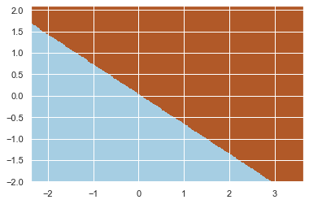

```python
areaCluster()
```

```python
def plotCentroides(pca_, modelo):
    # Plot dos centroides
    plt.plot(pca_[:, 0], pca_[:, 1], 'k.', markersize = 4)
    centroids = modelo.cluster_centers_
    inert = modelo.inertia_
    plt.scatter(centroids[:, 0], centroids[:, 1], marker = 'x', s = 169, linewidths = 3, color = 'r', zorder = 8)
    plt.xlim(x_min, x_max)
    plt.ylim(y_min, y_max)
    plt.xticks(())
    plt.yticks(())
    plt.show()
```

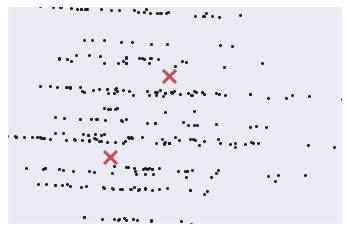

```python
plotCentroides(pca, modelo_v1)
```

O Silhouette score varia entre -1 e 1, quanto mais próximo de 1 melhor.

```python
?silhouette_score
```

```python
# Silhouette Score
labels = modelo_v1.labels_
silhouette_score(pca, labels, metric = 'euclidean')
```

```
0.33460910639009167
```

O segundo modelo iremos utilizar dados balanceados.

```python
x_full_resample = np.concatenate([x_train_resample, x_test])
```

```python
# Aplicando a redução de dimensionalidade
pca2 = PCA(n_components = 2)
pca2 = pca2.fit_transform(x_full_resample)
```

```python
modelo_v2 = KMeans(n_clusters = 2, random_state = seed_)
modelo_v2.fit(pca2)
```

```
KMeans(n_clusters=2, random_state=194)
```

```python
minMax(pca2, modelo_v2)
```

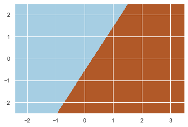

```python
areaCluster()
```

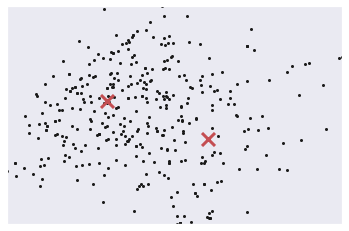

```python
plotCentroides(pca2, modelo_v2)
```

```python
# Silhouette Score
labels = modelo_v2.labels_
silhouette_score(pca2, labels, metric = 'euclidean')
```

```
0.3620117065146864
```

```python
# Modelo v3
# Iremos utilizados os dados normalizados com feature selecting

# Aplicando a redução de dimensionalidade
pca3 = PCA(n_components = 2)
pca3 = pca3.fit_transform(X_scaled_feature)

modelo_v3 = KMeans(n_clusters = 2, random_state = seed_)
modelo_v3.fit(pca3)

minMax(pca3, modelo_v3)
```

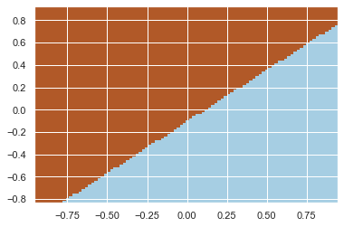

```python
areaCluster()
```

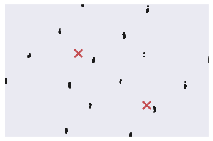

```python
plotCentroides(pca3, modelo_v3)
```

```python
# Silhouette Score
labels = modelo_v3.labels_
silhouette_score(pca3, labels, metric = 'euclidean')
```

```
0.41523707424145706
```

Analisando os resultados acima é tomada algumas conclusões. Primeiramente, como esperado não pode se esperar que um conjunto de dados para classificação possua bons resultados para clusterização. Temos isso representado no Silhouette Score de 0.41 do terceiro modelo, representando que o cluster possui tendência a não ser clusterizavel. Porém iremos seguir para um algoritmo mais complexo tentando extrair as previsões dos dados que possuimos.

Já é alertado que um dos problemas que iremos ter posteriormente é a pouca quantidade de dados, o que irá dificultar a aprendizagem do algoritmo.

## Observação

Irá ser adotado a nomeclatura 'VIVER' para o paciente que não tiver uma falha cardiovascular e 'MORRER' para o que tiver, essa nomeclatura foi adotada pois lendo artigos e outras submissões de notebooks do mesmo tipo, é preferivel adotar essa nomeclatura, já que uma falha cardiovascular desse tipo teria altas chances de levar o paciente a falecer.

Essa nomeclatura também tem relacão com o nome da variavel no dataset, 'DEATH_EVENT'.

## 6.2 SVM

```python
# Criação do modelo v1
modelo_svm_v1 = SVC(kernel = 'linear', random_state = seed_)
```

```python
# Criando base sem padronização, balanceamento e feature selecting
x_train_nothing, x_test_nothing, y_train_nothing, y_test_nothing =\
                                                train_test_split(X, y, test_size = .3, random_state = seed_)
```

```python
# Treinamento
start = time.time()
modelo_svm_v1.fit(x_train_nothing, y_train_nothing)
end = time.time()
print('Tempo de Treinamento do Modelo:', round(end - start, 4))
```

```
Tempo de Treinamento do Modelo: 3.9101
```

```python
pred_v1 = modelo_svm_v1.predict(x_test_nothing)
```

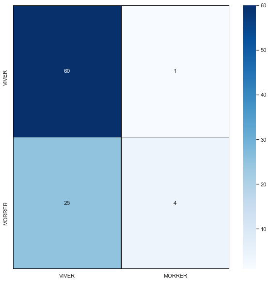

```
AUC: 0.560769
```

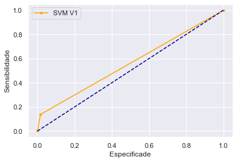

```
Acurácia: 0.711111
              precision    recall  f1-score   support

       VIVER       0.71      0.98      0.82        61
      MORRER       0.80      0.14      0.24        29

    accuracy                           0.71        90
   macro avg       0.75      0.56      0.53        90
weighted avg       0.74      0.71      0.63        90
```

```python
report_modelo(modelo_svm_v1, y_test_nothing, pred_v1, label = 'SVM V1', target_names = ['VIVER', 'MORRER'])
```

```python
# Criação do modelo v2
modelo_svm_v2 = SVC(kernel = 'linear', random_state = seed_)
```

```python
# Criando base sem balanceamento e feature selecting. Com padronização
sc = StandardScaler()
x_train_sc = sc.fit_transform(x_train_nothing)
x_test_sc = sc.fit_transform(x_test_nothing)
```

```python
# Treinamento
start = time.time()
modelo_svm_v2.fit(x_train_sc, y_train_nothing)
end = time.time()
print('Tempo de Treinamento do Modelo:', round(end - start, 4))
```

```
Tempo de Treinamento do Modelo: 0.002
```

```python
pred_v2 = modelo_svm_v2.predict(x_test_sc)
```

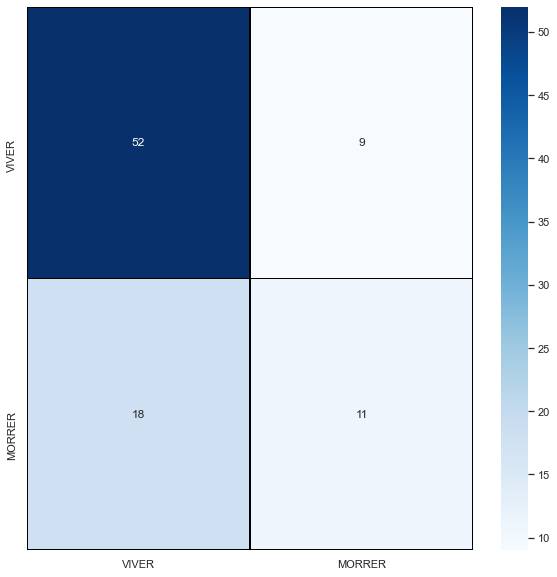

```
AUC: 0.615885
```

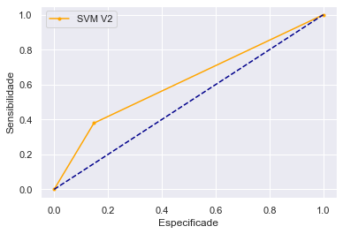

```
Acurácia: 0.700000
              precision    recall  f1-score   support

       VIVER       0.74      0.85      0.79        61
      MORRER       0.55      0.38      0.45        29

    accuracy                           0.70        90
   macro avg       0.65      0.62      0.62        90
weighted avg       0.68      0.70      0.68        90
```

```python
report_modelo(modelo_svm_v2, y_test_nothing, pred_v2, label = 'SVM V2', target_names = ['VIVER', 'MORRER'])
```

```python
# Criação do modelo v3
modelo_svm_v3 = SVC(kernel = 'linear', random_state = seed_)
```

```python
# Criando sem feature selecting. Com padronização e balanceamento
oversample2 = SMOTE(random_state = seed_)
x_train_sc_resample, y_train_resample_2 = oversample2.fit_resample(x_train_sc, y_train_nothing)
```

```python
# Treinamento
start = time.time()
modelo_svm_v3.fit(x_train_sc_resample, y_train_resample_2)
end = time.time()
print('Tempo de Treinamento do Modelo:', round(end - start, 4))
```

```
Tempo de Treinamento do Modelo: 0.003
```

```python
pred_v3 = modelo_svm_v3.predict(x_test_sc)
```

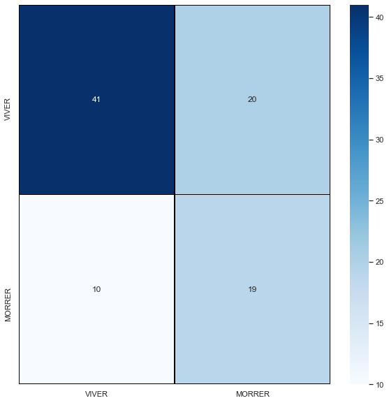

```
AUC: 0.663652
```

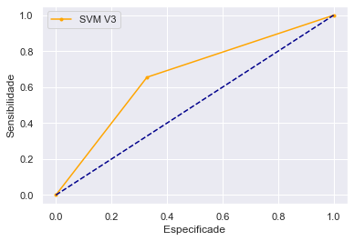

```
Acurácia: 0.666667
              precision    recall  f1-score   support

       VIVER       0.80      0.67      0.73        61
      MORRER       0.49      0.66      0.56        29

    accuracy                           0.67        90
   macro avg       0.65      0.66      0.65        90
weighted avg       0.70      0.67      0.68        90
```

```python
report_modelo(modelo_svm_v3, y_test_nothing, pred_v3, label = 'SVM V3', target_names = ['VIVER', 'MORRER'])
```

```python
# Criação do modelo v4
modelo_svm_v4 = SVC(kernel = 'linear', random_state = seed_)
```

```python
# Criando com padronização, balanceamento e feature selecting
# x_train_resample e x_test já possuem essas caracteristicas
```

```python
# Treinamento
start = time.time()
modelo_svm_v4.fit(x_train_resample, y_train_resample)
end = time.time()
print('Tempo de Treinamento do Modelo:', round(end - start, 4))
```

```
Tempo de Treinamento do Modelo: 0.003
```

```python
pred_v4 = modelo_svm_v4.predict(x_test)
```

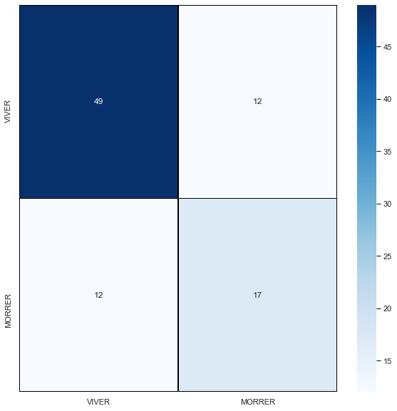

```
AUC: 0.694743
```

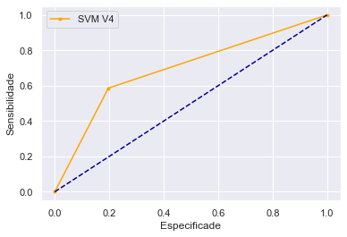

```
Acurácia: 0.733333
              precision    recall  f1-score   support

       VIVER       0.80      0.80      0.80        61
      MORRER       0.59      0.59      0.59        29

    accuracy                           0.73        90
   macro avg       0.69      0.69      0.69        90
weighted avg       0.73      0.73      0.73        90
```

```python
report_modelo(modelo_svm_v4, y_test, pred_v4, label = 'SVM V4', target_names = ['VIVER', 'MORRER'])
```

Agora iremos utilizar o grid e random search cv, para termos uma ideia inicial dos melhores hiperparametros do algoritmo.

```python
def treina_GridSearchCV(modelo, params_, x_treino, y_treino, x_teste, y_teste,\
                        n_jobs = 20, cv = 5, refit = True, title = 'SVM', scoring = None, salvar_resultados = False,\
                       report_treino = False):
    grid = GridSearchCV(modelo, params_, n_jobs = n_jobs, cv = cv, refit = refit, scoring = scoring)

    grid.fit(x_treino, y_treino)
    pred = grid.predict(x_teste)
    modelo_ = grid.best_estimator_

    print(grid.best_params_)

    target_names = ['VIVER', 'MORRER']

    print('Report Para Dados de Teste')

    report_modelo(modelo_, y_teste, pred, label = title, target_names = target_names)

    if report_treino:
        print('Report Para Dados de Treino')
        pred_treino = grid.predict(x_treino)

        # Acurácia
        print("Acurácia: %f" % accuracy_score(y_treino, pred_treino))

        # Classification Report
        print(classification_report(y_treino, pred_treino, target_names= target_names))

    if salvar_resultados:
        resultados_df = pd.DataFrame(grid.cv_results_)

        return resultados_df
```

```python
# Criação do modelo intenso 05

params = {
    'kernel': ['linear', 'poly', 'rbf', 'sigmoid'],
    'C': [0.9, 1.0, 1.1],
    'gamma': ['scale', 'auto'],
    'class_weight': ['balanced'],
    'random_state': [seed_]
}
```

```
{'C': 1.1, 'class_weight': 'balanced', 'gamma': 'scale', 'kernel': 'linear', 'random_state': 194}
```

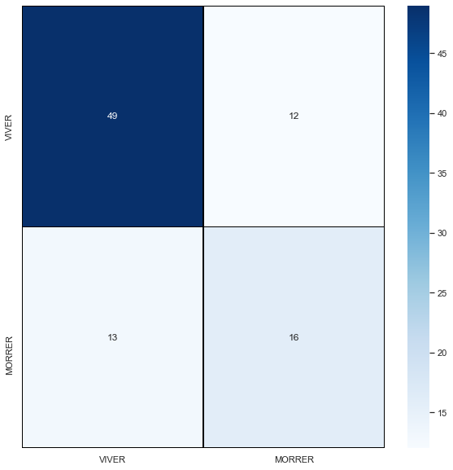

```
AUC: 0.677501
```

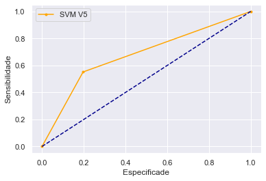

```
Acurácia: 0.722222
              precision    recall  f1-score   support

       VIVER       0.79      0.80      0.80        61
      MORRER       0.57      0.55      0.56        29

    accuracy                           0.72        90
   macro avg       0.68      0.68      0.68        90
weighted avg       0.72      0.72      0.72        90

Wall time: 2.17 s
```

```python
%%time
treina_GridSearchCV(SVC(), params, x_train_resample, y_train_resample, x_test, y_test, title = 'SVM V5', cv = 10)
```

```python
# Criação do modelo intenso 06

params = {
    'kernel': ['linear', 'poly', 'rbf', 'sigmoid'],
    'C': [0.9, 1.0, 1.1],
    'gamma': ['scale', 'auto', 0.1, 1, 10],
    'class_weight': ['balanced', {0:1, 1:5}, {0:1, 1:10}],
    'random_state': [seed_]
}
```

```
{'C': 0.9, 'class_weight': 'balanced', 'gamma': 'scale', 'kernel': 'linear', 'random_state': 194}
```

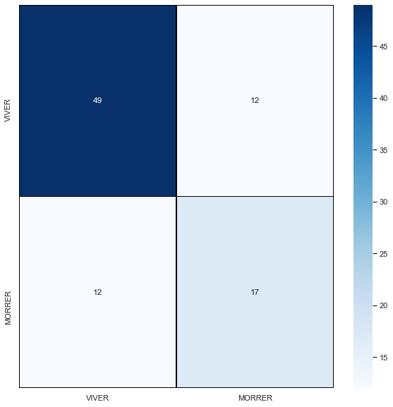

```
AUC: 0.694743
```

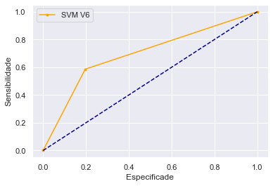

```
Acurácia: 0.733333
              precision    recall  f1-score   support

       VIVER       0.80      0.80      0.80        61
      MORRER       0.59      0.59      0.59        29

    accuracy                           0.73        90
   macro avg       0.69      0.69      0.69        90
weighted avg       0.73      0.73      0.73        90

Wall time: 2min 13s
```

```python
%%time
treina_GridSearchCV(SVC(), params, x_train_resample, y_train_resample, x_test, y_test, title = 'SVM V6')
```

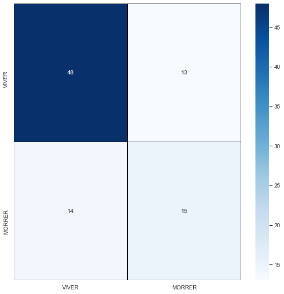

```
AUC: 0.652063
```

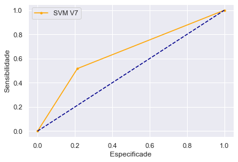

```
Acurácia: 0.700000
              precision    recall  f1-score   support

       VIVER       0.77      0.79      0.78        61
      MORRER       0.54      0.52      0.53        29

    accuracy                           0.70        90
   macro avg       0.65      0.65      0.65        90
weighted avg       0.70      0.70      0.70        90

Wall time: 243 ms
```

```python
%%time

# Criação do modelo 07
modelo_svm_v7 = SVC(C = 1.1, class_weight = 'balanced', gamma = 'scale', kernel = 'rbf', random_state = seed_)

# Treinamento
modelo_svm_v7.fit(x_train_resample, y_train_resample)

# Previsão
pred_v7 = modelo_svm_v7.predict(x_test)

# Report Geral
report_modelo(modelo_svm_v7, y_test, pred_v7, label = 'SVM V7', target_names = ['VIVER', 'MORRER'])
```

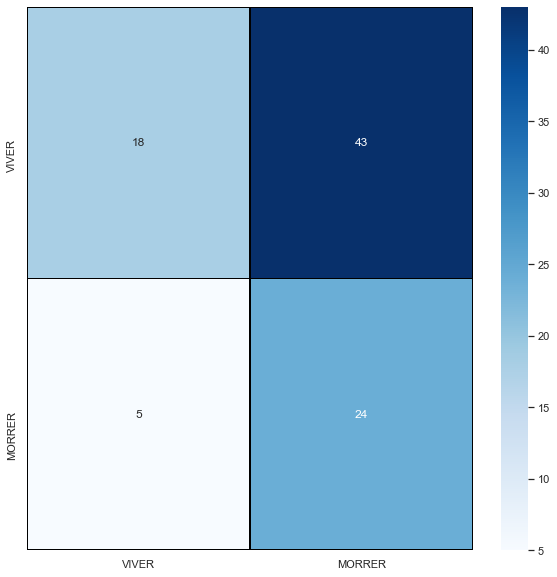

```
AUC: 0.561334
```

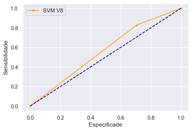

```
Acurácia: 0.466667
              precision    recall  f1-score   support

       VIVER       0.78      0.30      0.43        61
      MORRER       0.36      0.83      0.50        29

    accuracy                           0.47        90
   macro avg       0.57      0.56      0.46        90
weighted avg       0.65      0.47      0.45        90

Wall time: 259 ms
```

```python
%%time

# Criação do modelo 08
modelo_svm_v8 = SVC(C = 1000, class_weight = {0:1, 1:10}, gamma = 0.01, kernel = 'rbf', random_state = seed_)

# Treinamento
modelo_svm_v8.fit(x_train_resample, y_train_resample)

# Previsão
pred_v8 = modelo_svm_v8.predict(x_test)

# Report Geral
report_modelo(modelo_svm_v8, y_test, pred_v8, label = 'SVM V8', target_names = ['VIVER', 'MORRER'])
```

```python
class_weights = class_weight.compute_class_weight('balanced', np.unique(y_train_resample), y_train_resample)
```

```python
class_weights
```

```
array([1., 1.])
```

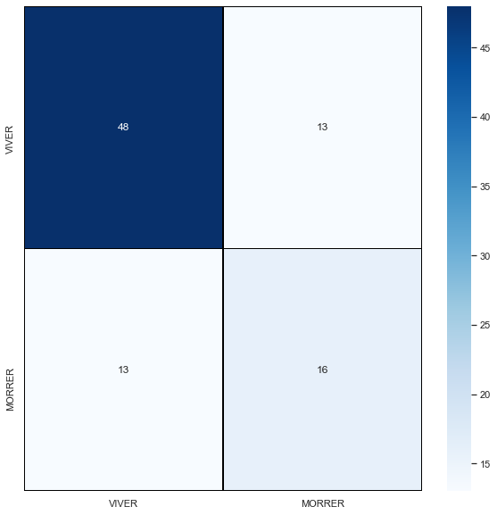

```
AUC: 0.669305
```

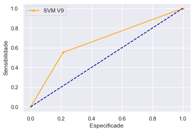

```
Acurácia: 0.711111
              precision    recall  f1-score   support

       VIVER       0.79      0.79      0.79        61
      MORRER       0.55      0.55      0.55        29

    accuracy                           0.71        90
   macro avg       0.67      0.67      0.67        90
weighted avg       0.71      0.71      0.71        90

Wall time: 251 ms
```

```python
%%time

# Criação do modelo 09
modelo_svm_v9 = SVC(C = 1000, class_weight = {0: 1, 1: 1}, gamma = 0.01, kernel = 'rbf', random_state = seed_)

# Treinamento
modelo_svm_v9.fit(x_train_resample, y_train_resample)

# Previsão
pred_v9 = modelo_svm_v9.predict(x_test)

# Report Geral
report_modelo(modelo_svm_v9, y_test, pred_v9, label = 'SVM V9', target_names = ['VIVER', 'MORRER'])
```

```python
# Criação do modelo intenso 10

params = {
    'kernel': ['rbf'],
    'C': [0.001, 0.01, 0.1, 1, 10, 100],
    'gamma': ['scale', 'auto', 1, 10, 100],
    'class_weight': ['balanced'],
    'random_state': [seed_]
}
```

```
{'C': 0.001, 'class_weight': 'balanced', 'gamma': 'scale', 'kernel': 'rbf', 'random_state': 194}
```

```
AUC: 0.703787
```

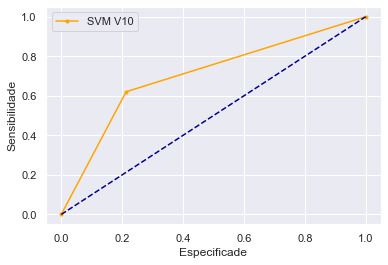

```
Acurácia: 0.733333
              precision    recall  f1-score   support

       VIVER       0.81      0.79      0.80        61
      MORRER       0.58      0.62      0.60        29

    accuracy                           0.73        90
   macro avg       0.70      0.70      0.70        90
weighted avg       0.74      0.73      0.74        90

Wall time: 1.25 s
```

```python
%%time
treina_GridSearchCV(SVC(), params, x_train_resample, y_train_resample, x_test, y_test,\
                    title = 'SVM V10', scoring = 'top_k_accuracy')
```

```python
# Criação do modelo intenso 11

params = {
    'kernel': ['rbf'],
    'C': [0.0001, 0.001, 0.01, 0.1, 1, 10],
    'gamma': ['scale', 'auto', 1, 10, 100],
    'class_weight': ['balanced'],
    'random_state': [seed_]
}
```

```
{'C': 0.0001, 'class_weight': 'balanced', 'gamma': 'scale', 'kernel': 'rbf', 'random_state': 194}
```

```
AUC: 0.703787
```

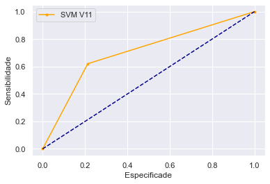

```
Acurácia: 0.733333
              precision    recall  f1-score   support

       VIVER       0.81      0.79      0.80        61
      MORRER       0.58      0.62      0.60        29

    accuracy                           0.73        90
   macro avg       0.70      0.70      0.70        90
weighted avg       0.74      0.73      0.74        90

Wall time: 630 ms
```

```python
%%time
resultados = treina_GridSearchCV(SVC(), params, x_train_resample, y_train_resample, x_test, y_test,\
                    title = 'SVM V11', scoring = 'top_k_accuracy', salvar_resultados = True)
```

```python
resultados[['param_C', 'param_class_weight', 'param_gamma', 'param_kernel',\
            'mean_test_score', 'std_test_score', 'rank_test_score']]
```

|  | param_C | param_class_weight | param_gamma | param_kernel | mean_test_score | std_test_score | rank_test_score |
| --- | --- | --- | --- | --- | --- | --- | --- |
| 0 | 0.0001 | balanced | scale | rbf | 1.0 | 0.0 | 1 |
| 1 | 0.0001 | balanced | auto | rbf | 1.0 | 0.0 | 1 |
| 2 | 0.0001 | balanced | 1 | rbf | 1.0 | 0.0 | 1 |
| 3 | 0.0001 | balanced | 10 | rbf | 1.0 | 0.0 | 1 |
| 4 | 0.0001 | balanced | 100 | rbf | 1.0 | 0.0 | 1 |
| 5 | 0.001 | balanced | scale | rbf | 1.0 | 0.0 | 1 |
| 6 | 0.001 | balanced | auto | rbf | 1.0 | 0.0 | 1 |
| 7 | 0.001 | balanced | 1 | rbf | 1.0 | 0.0 | 1 |
| 8 | 0.001 | balanced | 10 | rbf | 1.0 | 0.0 | 1 |
| 9 | 0.001 | balanced | 100 | rbf | 1.0 | 0.0 | 1 |
| 10 | 0.01 | balanced | scale | rbf | 1.0 | 0.0 | 1 |
| 11 | 0.01 | balanced | auto | rbf | 1.0 | 0.0 | 1 |
| 12 | 0.01 | balanced | 1 | rbf | 1.0 | 0.0 | 1 |
| 13 | 0.01 | balanced | 10 | rbf | 1.0 | 0.0 | 1 |
| 14 | 0.01 | balanced | 100 | rbf | 1.0 | 0.0 | 1 |
| 15 | 0.1 | balanced | scale | rbf | 1.0 | 0.0 | 1 |
| 16 | 0.1 | balanced | auto | rbf | 1.0 | 0.0 | 1 |
| 17 | 0.1 | balanced | 1 | rbf | 1.0 | 0.0 | 1 |
| 18 | 0.1 | balanced | 10 | rbf | 1.0 | 0.0 | 1 |
| 19 | 0.1 | balanced | 100 | rbf | 1.0 | 0.0 | 1 |
| 20 | 1 | balanced | scale | rbf | 1.0 | 0.0 | 1 |
| 21 | 1 | balanced | auto | rbf | 1.0 | 0.0 | 1 |
| 22 | 1 | balanced | 1 | rbf | 1.0 | 0.0 | 1 |
| 23 | 1 | balanced | 10 | rbf | 1.0 | 0.0 | 1 |
| 24 | 1 | balanced | 100 | rbf | 1.0 | 0.0 | 1 |
| 25 | 10 | balanced | scale | rbf | 1.0 | 0.0 | 1 |
| 26 | 10 | balanced | auto | rbf | 1.0 | 0.0 | 1 |
| 27 | 10 | balanced | 1 | rbf | 1.0 | 0.0 | 1 |
| 28 | 10 | balanced | 10 | rbf | 1.0 | 0.0 | 1 |
| 29 | 10 | balanced | 100 | rbf | 1.0 | 0.0 | 1 |

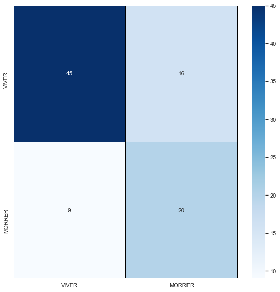

```
AUC: 0.713680
```

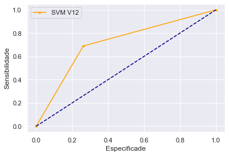

```
Acurácia: 0.722222
              precision    recall  f1-score   support

       VIVER       0.83      0.74      0.78        61
      MORRER       0.56      0.69      0.62        29

    accuracy                           0.72        90
   macro avg       0.69      0.71      0.70        90
weighted avg       0.74      0.72      0.73        90

Report Para Dados de Treino

Acurácia: 0.725352
              precision    recall  f1-score   support

       VIVER       0.78      0.63      0.70       142
      MORRER       0.69      0.82      0.75       142

    accuracy                           0.73       284
   macro avg       0.73      0.73      0.72       284
weighted avg       0.73      0.73      0.72       284

Wall time: 257 ms
```

```python
%%time

# Criação do modelo 12
modelo_svm_v12 = SVC(C = 100, class_weight = {0: 1, 1: 1.3}, gamma = 0.0001, kernel = 'rbf', random_state = seed_)

# Treinamento
modelo_svm_v12.fit(x_train_resample, y_train_resample)

# Previsão
pred_v12 = modelo_svm_v12.predict(x_test)

# Report Geral
report_modelo(modelo_svm_v12, y_test, pred_v12, label = 'SVM V12', target_names = ['VIVER', 'MORRER'])

print('Report Para Dados de Treino\n')

pred_treino = modelo_svm_v12.predict(x_train_resample)

print("Acurácia: %f" % accuracy_score(y_train_resample, pred_treino))

# Classification Report
print(classification_report(y_train_resample, pred_treino, target_names= ['VIVER', 'MORRER']))
```

```python
# Criação do modelo intenso 12

params = {
    'kernel': ['rbf'],
    'C': [0.0001, 0.001, 0.01, 0.1, 1, 10],
    'gamma': [0.001, 0.01, 1, 10, 100],
    'class_weight': ['balanced'],
    'random_state': [seed_]
}
```

```
{'C': 0.0001, 'class_weight': 'balanced', 'gamma': 0.001, 'kernel': 'rbf', 'random_state': 194}
Report Para Dados de Teste
```

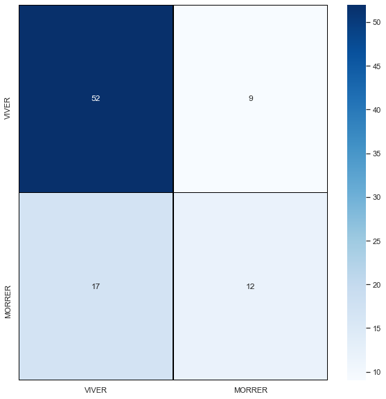

```
AUC: 0.633126
```

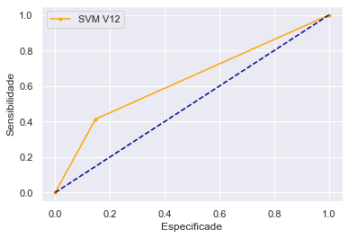

```
Acurácia: 0.711111
              precision    recall  f1-score   support

       VIVER       0.75      0.85      0.80        61
      MORRER       0.57      0.41      0.48        29

    accuracy                           0.71        90
   macro avg       0.66      0.63      0.64        90
weighted avg       0.69      0.71      0.70        90

Report Para Dados de Treino
              precision    recall  f1-score   support

       VIVER       0.65      0.87      0.74       142
      MORRER       0.81      0.53      0.64       142

    accuracy                           0.70       284
   macro avg       0.73      0.70      0.69       284
weighted avg       0.73      0.70      0.69       284

Wall time: 1.32 s
```

```python
%%time
resultados = treina_GridSearchCV(SVC(), params, x_train_resample, y_train_resample, x_test, y_test,\
                    title = 'SVM V12', scoring = 'top_k_accuracy', salvar_resultados = True, report_treino = True)
```

```python
resultados[['param_C', 'param_class_weight', 'param_gamma', 'param_kernel',\
            'mean_test_score', 'std_test_score', 'rank_test_score']]
```

|  | param_C | param_class_weight | param_gamma | param_kernel | mean_test_score | std_test_score | rank_test_score |
| --- | --- | --- | --- | --- | --- | --- | --- |
| 0 | 0.0001 | balanced | 0.001 | rbf | 1.0 | 0.0 | 1 |
| 1 | 0.0001 | balanced | 0.01 | rbf | 1.0 | 0.0 | 1 |
| 2 | 0.0001 | balanced | 1 | rbf | 1.0 | 0.0 | 1 |
| 3 | 0.0001 | balanced | 10 | rbf | 1.0 | 0.0 | 1 |
| 4 | 0.0001 | balanced | 100 | rbf | 1.0 | 0.0 | 1 |
| 5 | 0.001 | balanced | 0.001 | rbf | 1.0 | 0.0 | 1 |
| 6 | 0.001 | balanced | 0.01 | rbf | 1.0 | 0.0 | 1 |
| 7 | 0.001 | balanced | 1 | rbf | 1.0 | 0.0 | 1 |
| 8 | 0.001 | balanced | 10 | rbf | 1.0 | 0.0 | 1 |
| 9 | 0.001 | balanced | 100 | rbf | 1.0 | 0.0 | 1 |
| 10 | 0.01 | balanced | 0.001 | rbf | 1.0 | 0.0 | 1 |
| 11 | 0.01 | balanced | 0.01 | rbf | 1.0 | 0.0 | 1 |
| 12 | 0.01 | balanced | 1 | rbf | 1.0 | 0.0 | 1 |
| 13 | 0.01 | balanced | 10 | rbf | 1.0 | 0.0 | 1 |
| 14 | 0.01 | balanced | 100 | rbf | 1.0 | 0.0 | 1 |
| 15 | 0.1 | balanced | 0.001 | rbf | 1.0 | 0.0 | 1 |
| 16 | 0.1 | balanced | 0.01 | rbf | 1.0 | 0.0 | 1 |
| 17 | 0.1 | balanced | 1 | rbf | 1.0 | 0.0 | 1 |
| 18 | 0.1 | balanced | 10 | rbf | 1.0 | 0.0 | 1 |
| 19 | 0.1 | balanced | 100 | rbf | 1.0 | 0.0 | 1 |
| 20 | 1 | balanced | 0.001 | rbf | 1.0 | 0.0 | 1 |
| 21 | 1 | balanced | 0.01 | rbf | 1.0 | 0.0 | 1 |
| 22 | 1 | balanced | 1 | rbf | 1.0 | 0.0 | 1 |
| 23 | 1 | balanced | 10 | rbf | 1.0 | 0.0 | 1 |
| 24 | 1 | balanced | 100 | rbf | 1.0 | 0.0 | 1 |
| 25 | 10 | balanced | 0.001 | rbf | 1.0 | 0.0 | 1 |
| 26 | 10 | balanced | 0.01 | rbf | 1.0 | 0.0 | 1 |
| 27 | 10 | balanced | 1 | rbf | 1.0 | 0.0 | 1 |
| 28 | 10 | balanced | 10 | rbf | 1.0 | 0.0 | 1 |
| 29 | 10 | balanced | 100 | rbf | 1.0 | 0.0 | 1 |

O nosso modelo tende que a aumentar o recall para a classe 1 (MORRER) quando aumenta o 'C' e diminui o 'Gamma', porém o Recall também cai para a classe 0 (Viver). Tentando ajustar os parâmetros para ter um tradeoff ideal, não se mostrou favoravel. O problema esta na quantidade de dados.

## 6.3 XGBOOST

O modelo de SVM não conseguiu encontrar os melhores vetores de suporte para separar os nossos dados com uma margem consideravel. Analisando os resultados o nosso modelo não aparenta estar sofrendo de overfitting. O nosso problema esta no tamanho do nosso dataset, possuimos poucos dados, para tentar melhorar o nosso Recall, iremos utilizar o algoritmo XGBoost, esse possui desempenhos melhores em dataset menores, pois combina multiplos algoritmos para realizar as predições, esse que pertence a familia dos ensemble.

```python
# Transformando os dados em DMatrix pois o XGBoost exige
dtrain_nothing = xgb.DMatrix(x_train_nothing, label = y_train_nothing)
dtest_nothing = xgb.DMatrix(x_test_nothing, label = y_test_nothing)
```

```python
# Definindo parametros e configurações
param = {}
```

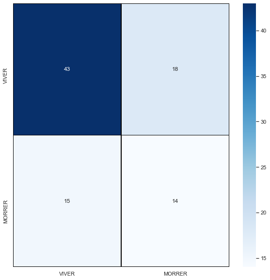

```
AUC: 0.593838
```

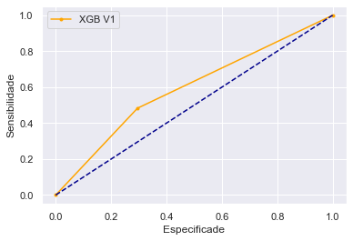

```
Acurácia: 0.633333
              precision    recall  f1-score   support

       VIVER       0.74      0.70      0.72        61
      MORRER       0.44      0.48      0.46        29

    accuracy                           0.63        90
   macro avg       0.59      0.59      0.59        90
weighted avg       0.64      0.63      0.64        90
```

```python
# Criação do modelo base v1
# Criando base sem padronização, balanceamento e feature selecting
modelo_xgb_v1 = xgb.train(params = param, dtrain = dtrain_nothing)

pred_v1 = modelo_xgb_v1.predict(dtest_nothing)

report_modelo(modelo_xgb_v1, y_test_nothing, pred_v1, label = 'XGB V1', target_names = ['VIVER', 'MORRER'])
```

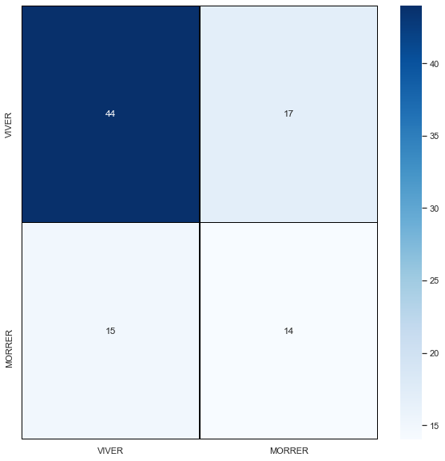

```
AUC: 0.602035
```

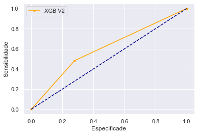

```
Acurácia: 0.644444
              precision    recall  f1-score   support

       VIVER       0.75      0.72      0.73        61
      MORRER       0.45      0.48      0.47        29

    accuracy                           0.64        90
   macro avg       0.60      0.60      0.60        90
weighted avg       0.65      0.64      0.65        90
```

```python
# Transformando os dados em DMatrix pois o XGBoost exige
dtrain_sc = xgb.DMatrix(x_train_sc, label = y_train_nothing)
dtest_sc = xgb.DMatrix(x_test_sc, label = y_test_nothing)

# Criação do modelo base v2
# Criando base sem balanceamento e feature selecting. Com padronização
modelo_xgb_v2 = xgb.train(params = param, dtrain = dtrain_sc)

pred_v2 = modelo_xgb_v2.predict(dtest_sc)

report_modelo(modelo_xgb_v2, y_test_nothing, pred_v2, label = 'XGB V2', target_names = ['VIVER', 'MORRER'])
```

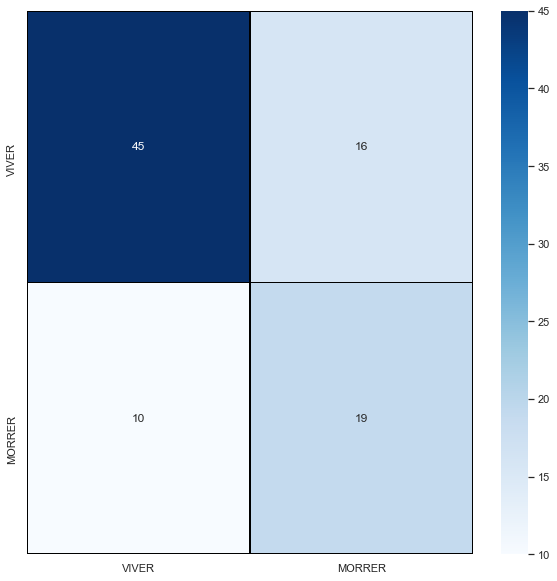

```
AUC: 0.696439
```

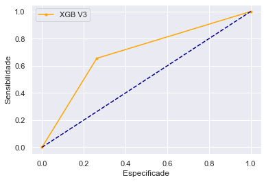

```
Acurácia: 0.711111
              precision    recall  f1-score   support

       VIVER       0.82      0.74      0.78        61
      MORRER       0.54      0.66      0.59        29

    accuracy                           0.71        90
   macro avg       0.68      0.70      0.68        90
weighted avg       0.73      0.71      0.72        90
```

```python
# Transformando os dados em DMatrix pois o XGBoost exige
dtrain_sc_resample = xgb.DMatrix(x_train_sc_resample, label = y_train_resample_2)
dtest_sc = xgb.DMatrix(x_test_sc, label = y_test_nothing)

# Criação do modelo base v3
# Criando sem feature selecting. Com padronização e balanceamento
modelo_xgb_v3 = xgb.train(params = param, dtrain = dtrain_sc_resample)

pred_v3 = modelo_xgb_v3.predict(dtest_sc)

report_modelo(modelo_xgb_v3, y_test_nothing, pred_v3, label = 'XGB V3', target_names = ['VIVER', 'MORRER'])
```

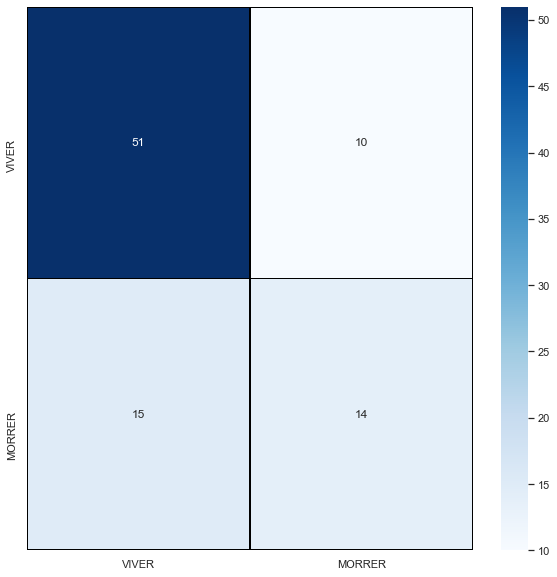

```
AUC: 0.659412
```

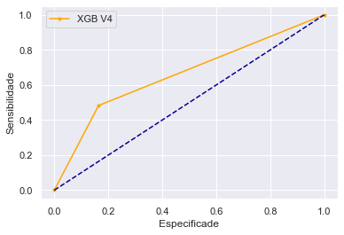

```
Acurácia: 0.722222
              precision    recall  f1-score   support

       VIVER       0.77      0.84      0.80        61
      MORRER       0.58      0.48      0.53        29

    accuracy                           0.72        90
   macro avg       0.68      0.66      0.67        90
weighted avg       0.71      0.72      0.71        90
```

```python
# Transformando os dados em DMatrix pois o XGBoost exige
dtrain = xgb.DMatrix(x_train_resample, label = y_train_resample)
dtest = xgb.DMatrix(x_test, label = y_test)

# Criação do modelo base v4
# Criando com padronização, balanceamento e feature selecting
modelo_xgb_v4 = xgb.train(params = param, dtrain = dtrain)

pred_v4 = modelo_xgb_v4.predict(dtest)

report_modelo(modelo_xgb_v4, y_test_nothing, pred_v4, label = 'XGB V4', target_names = ['VIVER', 'MORRER'])
```

Para o algoritmo XGBoost o modelo que melhor apresentou resultado foi a terceira versão sem feature selecting,com padronização e balanceamento. Esse modelo também apresentou um aumento na sua Especificidade podendo causar um futuro overfitting. Iremos tentar otimizar os parâmetros evitando o overfitting.

```python
params = {
        'min_child_weight': [1, 5, 10],
        'gamma': [0.5, 1, 1.5, 2, 5],
        'subsample': [0.6, 0.8, 1.0],
        'colsample_bytree': [0.6, 0.8, 1.0],
        'max_depth': [3, 4, 5],
        'learning_rate': [0.3, 0.2, 0.1, 0.05],
        'nthread': [2]
        }
```

```
[17:22:41] WARNING: C:/Users/Administrator/workspace/xgboost-win64_release_1.4.0/src/learner.cc:1095: Starting in XGBoost 1.3.0, the default evaluation metric used with the objective 'binary:logistic' was changed from 'error' to 'logloss'. Explicitly set eval_metric if you'd like to restore the old …
{'colsample_bytree': 0.8, 'gamma': 0.5, 'learning_rate': 0.2, 'max_depth': 4, 'min_child_weight': 1, 'nthread': 2, 'subsample': 1.0}
Report Para Dados de Teste
```

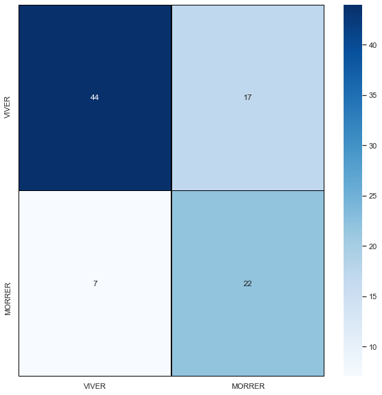

```
AUC: 0.739966
```

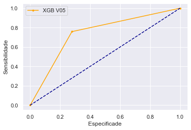

```
Acurácia: 0.733333
              precision    recall  f1-score   support

       VIVER       0.86      0.72      0.79        61
      MORRER       0.56      0.76      0.65        29

    accuracy                           0.73        90
   macro avg       0.71      0.74      0.72        90
weighted avg       0.77      0.73      0.74        90

Report Para Dados de Treino
Acurácia: 1.000000
              precision    recall  f1-score   support

       VIVER       1.00      1.00      1.00       142
      MORRER       1.00      1.00      1.00       142

    accuracy                           1.00       284
   macro avg       1.00      1.00      1.00       284
weighted avg       1.00      1.00      1.00       284

Wall time: 22.5 s
```

```python
%%time
# Criação do modelo v5
# Criando sem feature selecting. Com padronização e balanceamento

treina_GridSearchCV(xgb.XGBClassifier(use_label_encoder = False), params, x_train_sc_resample, y_train_resample_2,\
                                 x_test_sc, y_test_nothing, title = 'XGB V05', report_treino = True)
```

```python
params = {
        'min_child_weight': [1, 5, 10],
        'gamma': [0.5, 1, 1.5, 2, 5],
        'subsample': [0.6, 0.8, 1.0],
        'colsample_bytree': [0.6, 0.8, 1.0],
        'max_depth': [3, 4, 5],
        'learning_rate': [0.3, 0.2, 0.1, 0.05],
        'nthread': [2]
        }
```

```
[17:24:47] WARNING: C:/Users/Administrator/workspace/xgboost-win64_release_1.4.0/src/learner.cc:1095: Starting in XGBoost 1.3.0, the default evaluation metric used with the objective 'binary:logistic' was changed from 'error' to 'logloss'. Explicitly set eval_metric if you'd like to restore the old …
{'colsample_bytree': 1.0, 'gamma': 2, 'learning_rate': 0.3, 'max_depth': 4, 'min_child_weight': 1, 'nthread': 2, 'subsample': 0.8}
Report Para Dados de Teste
```

```
AUC: 0.702940
```

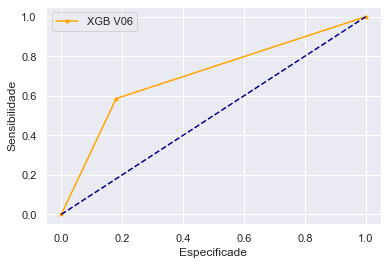

```
Acurácia: 0.744444
              precision    recall  f1-score   support

       VIVER       0.81      0.82      0.81        61
      MORRER       0.61      0.59      0.60        29

    accuracy                           0.74        90
   macro avg       0.71      0.70      0.70        90
weighted avg       0.74      0.74      0.74        90

Report Para Dados de Treino
Acurácia: 0.904930
              precision    recall  f1-score   support

       VIVER       0.90      0.92      0.91       142
      MORRER       0.91      0.89      0.90       142

    accuracy                           0.90       284
   macro avg       0.91      0.90      0.90       284
weighted avg       0.91      0.90      0.90       284

Wall time: 20.7 s
```

```python
%%time
# Criação do modelo v6
# Criando com padronização, balanceamento e feature selecting

treina_GridSearchCV(xgb.XGBClassifier(use_label_encoder = False), params, x_train_resample, y_train_resample,\
                                 x_test, y_test, title = 'XGB V06', report_treino = True)
```

```
[17:33:25] WARNING: C:/Users/Administrator/workspace/xgboost-win64_release_1.4.0/src/learner.cc:1095: Starting in XGBoost 1.3.0, the default evaluation metric used with the objective 'binary:logistic' was changed from 'error' to 'logloss'. Explicitly set eval_metric if you'd like to restore the old …
{'colsample_bytree': 1.0, 'gamma': 2, 'learning_rate': 0.3, 'max_depth': 4, 'min_child_weight': 1, 'nthread': 2, 'subsample': 0.8}
Report Para Dados de Teste
```

```
AUC: 0.702940
```

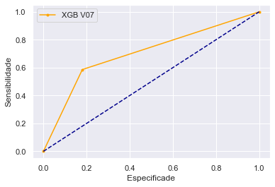

```
Acurácia: 0.744444
              precision    recall  f1-score   support

       VIVER       0.81      0.82      0.81        61
      MORRER       0.61      0.59      0.60        29

    accuracy                           0.74        90
   macro avg       0.71      0.70      0.70        90
weighted avg       0.74      0.74      0.74        90

Report Para Dados de Treino
Acurácia: 0.904930
              precision    recall  f1-score   support

       VIVER       0.90      0.92      0.91       142
      MORRER       0.91      0.89      0.90       142

    accuracy                           0.90       284
   macro avg       0.91      0.90      0.90       284
weighted avg       0.91      0.90      0.90       284

Wall time: 28.9 s
```

```python
%%time

params = {
        'min_child_weight': [1, 2, 3],
        'gamma': [1, 1.5, 2, 3],
        'subsample': [0.6, 0.8, 1.0],
        'colsample_bytree': [0.6, 0.8, 1.0],
        'max_depth': [2, 3, 4, 5],
        'learning_rate': [0.4, 0.3, 0.2, 0.1, 0.05],
        'nthread': [2]
        }

# Criação do modelo v7
# Criando com padronização, balanceamento e feature selecting
treina_GridSearchCV(xgb.XGBClassifier(use_label_encoder = False), params, x_train_resample, y_train_resample,\
                                 x_test, y_test, title = 'XGB V07', report_treino = True)
```

```
[17:50:35] WARNING: C:/Users/Administrator/workspace/xgboost-win64_release_1.4.0/src/learner.cc:573:
Parameters: { "early_stopping_rounds", "num_boost_round" } might not be used.

  This may not be accurate due to some parameters are only used in language bindings but
  passed down to XGBoost core.  Or some parameters are not used but slip through this
  verification. Please open an issue if you find above cases.


[17:50:35] WARNING: C:/Users/Administrator/workspace/xgboost-win64_release_1.4.0/src/learner.cc:1095: Starting in XGBoost 1.3.0, the default evaluation metric used with the objective 'binary:logistic' was changed from 'error' to 'logloss'. Explicitly set eval_metric if you'd like to restore the old …
{'colsample_bytree': 1.0, 'gamma': 1.5, 'learning_rate': 0.5, 'max_depth': 6, 'min_child_weight': 3, 'nthread': 2, 'subsample': 0.8}
Report Para Dados de Teste
```

```
One or more of the test scores are non-finite: [0.70789474 0.72537594 0.76409774 ...        nan        nan        nan]
```

```
AUC: 0.703787
```

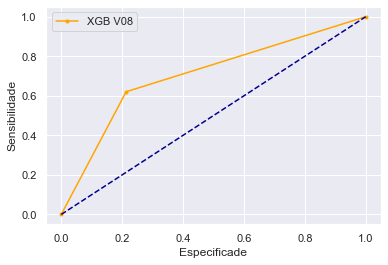

```
Acurácia: 0.733333
              precision    recall  f1-score   support

       VIVER       0.81      0.79      0.80        61
      MORRER       0.58      0.62      0.60        29

    accuracy                           0.73        90
   macro avg       0.70      0.70      0.70        90
weighted avg       0.74      0.73      0.74        90

Report Para Dados de Treino
Acurácia: 0.897887
              precision    recall  f1-score   support

       VIVER       0.88      0.92      0.90       142
      MORRER       0.91      0.88      0.90       142

    accuracy                           0.90       284
   macro avg       0.90      0.90      0.90       284
weighted avg       0.90      0.90      0.90       284

Wall time: 4min 57s
```

```python
%%time

params = {
        'min_child_weight': [1, 2, 3, 4, 5, 6],
        'gamma': [0.5, 0.7, 1, 1.5, 2, 3],
        'subsample': [0.2, 0.4, 0.6, 0.8, 1.0],
        'colsample_bytree': [0.6, 0.8, 1.0, 1.2],
        'max_depth': [5, 6, 7, 8, 9],
        'learning_rate': [0.7, 0.6, 0.5, 0.4, 0.3, 0.2, 0.1, 0.05],
        'nthread': [2]
        }

# Criação do modelo v8
# Criando com padronização, balanceamento e feature selecting
modelo_grid = xgb.XGBClassifier(use_label_encoder = False, early_stopping_rounds = 10, num_boost_round = 999)
treina_GridSearchCV(modelo_grid, params, x_train_resample, y_train_resample,\
                                 x_test, y_test, title = 'XGB V08', report_treino = True)
```

[output not shown]

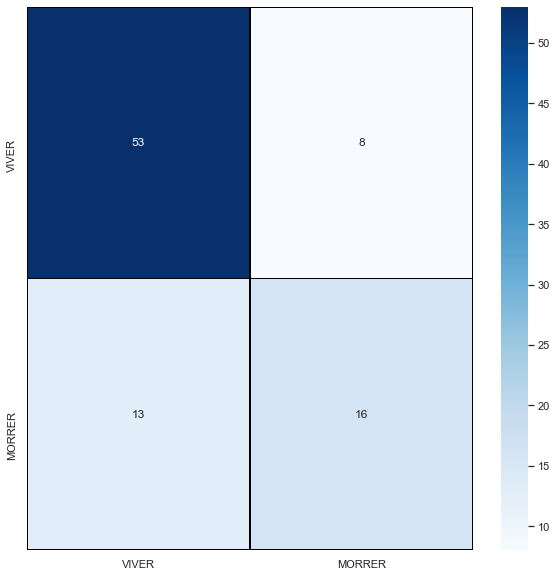

```
AUC: 0.710288
```

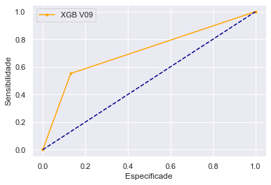

```
Acurácia: 0.766667
              precision    recall  f1-score   support

       VIVER       0.80      0.87      0.83        61
      MORRER       0.67      0.55      0.60        29

    accuracy                           0.77        90
   macro avg       0.73      0.71      0.72        90
weighted avg       0.76      0.77      0.76        90

Report Para Dados de Treino
Acurácia: 0.943662
              precision    recall  f1-score   support

       VIVER       0.94      0.94      0.94       142
      MORRER       0.94      0.94      0.94       142

    accuracy                           0.94       284
   macro avg       0.94      0.94      0.94       284
weighted avg       0.94      0.94      0.94       284

Wall time: 1min 58s
```

```python
%%time

params = {
        'min_child_weight': [2, 3, 4, 5],
        'gamma': [0.7, 1.3, 1.5, 1.7],
        'subsample': [0.6, 0.7, 0.8, 0.9, 1.0],
        'colsample_bytree': [0.6, 0.7, 0.8, 0.9, 1.0],
        'max_depth': [5, 6, 7],
        'learning_rate': [0.5, 0.1, 0.01],
        'nthread': [2],
        'n_estimators' : [500]
        }

# Criação do modelo v9
# Criando com padronização, balanceamento e feature selecting
modelo_grid = xgb.XGBClassifier(use_label_encoder = False)

resultados = treina_GridSearchCV(modelo_grid, params, x_train_resample, y_train_resample,\
                                 x_test, y_test, title = 'XGB V09', report_treino = True,\
                                 salvar_resultados = True)
```

```python
resultados
```

[output not shown]

```
[18:29:19] WARNING: C:/Users/Administrator/workspace/xgboost-win64_release_1.4.0/src/learner.cc:1095: Starting in XGBoost 1.3.0, the default evaluation metric used with the objective 'binary:logistic' was changed from 'error' to 'logloss'. Explicitly set eval_metric if you'd like to restore the old …
{'alpha': 0, 'colsample_bytree': 1.0, 'gamma': 1.5, 'lambda': 1, 'learning_rate': 0.5, 'max_depth': 6, 'min_child_weight': 3, 'n_estimators': 500, 'nthread': 2, 'subsample': 0.8}
Report Para Dados de Teste
```

```
AUC: 0.702940
```

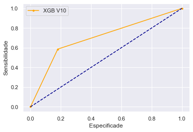

```
Acurácia: 0.744444
              precision    recall  f1-score   support

       VIVER       0.81      0.82      0.81        61
      MORRER       0.61      0.59      0.60        29

    accuracy                           0.74        90
   macro avg       0.71      0.70      0.70        90
weighted avg       0.74      0.74      0.74        90

Report Para Dados de Treino
Acurácia: 0.901408
              precision    recall  f1-score   support

       VIVER       0.88      0.93      0.90       142
      MORRER       0.93      0.87      0.90       142

    accuracy                           0.90       284
   macro avg       0.90      0.90      0.90       284
weighted avg       0.90      0.90      0.90       284

Wall time: 10min 38s
```

```python
%%time

params = {
        'min_child_weight': [2, 3, 4, 5],
        'gamma': [0.7, 1.3, 1.4, 1.5],
        'subsample': [0.6, 0.8, 0.9, 1.0],
        'colsample_bytree': [0.8, 0.9, 1.0],
        'max_depth': [5, 6, 7],
        'learning_rate': [0.5, 0.1, 0.01],
        'lambda': [0.9, 1, 1.1],
        'alpha': [0, 0.1],
        'nthread': [2],
        'n_estimators' : [500]
        }

# Criação do modelo v10
# Criando com padronização, balanceamento e feature selecting
modelo_grid = xgb.XGBClassifier(use_label_encoder = False)

resultados = treina_GridSearchCV(modelo_grid, params, x_train_resample, y_train_resample,\
                                 x_test, y_test, title = 'XGB V10', report_treino = True,\
                                 salvar_resultados = True)
```

```
[18:36:52] WARNING: C:/Users/Administrator/workspace/xgboost-win64_release_1.4.0/src/learner.cc:1095: Starting in XGBoost 1.3.0, the default evaluation metric used with the objective 'binary:logistic' was changed from 'error' to 'logloss'. Explicitly set eval_metric if you'd like to restore the old …
{'colsample_bytree': 0.9, 'gamma': 0.3, 'learning_rate': 0.5, 'max_depth': 6, 'min_child_weight': 2, 'n_estimators': 500, 'nthread': 2, 'subsample': 0.8}
Report Para Dados de Teste
```

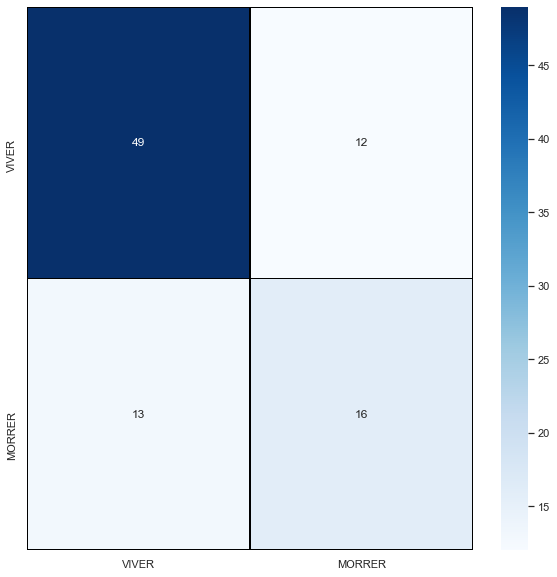

```
AUC: 0.677501
```

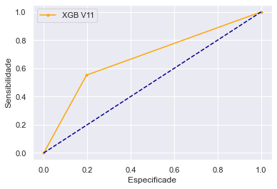

```
Acurácia: 0.722222
              precision    recall  f1-score   support

       VIVER       0.79      0.80      0.80        61
      MORRER       0.57      0.55      0.56        29

    accuracy                           0.72        90
   macro avg       0.68      0.68      0.68        90
weighted avg       0.72      0.72      0.72        90

Report Para Dados de Treino
Acurácia: 0.964789
              precision    recall  f1-score   support

       VIVER       0.96      0.97      0.97       142
      MORRER       0.97      0.96      0.96       142

    accuracy                           0.96       284
   macro avg       0.96      0.96      0.96       284
weighted avg       0.96      0.96      0.96       284

Wall time: 2min 16s
```

```python
%%time

params = {
        'min_child_weight': [1, 2, 3, 4, 5],
        'gamma': [0, 0.1, 0.2, 0.3],
        'subsample': [0.6, 0.8, 0.9, 1.0],
        'colsample_bytree': [0.8, 0.9, 1.0],
        'max_depth': [5, 6, 7],
        'learning_rate': [0.5, 0.1, 0.01],
        'nthread': [2],
        'n_estimators' : [500]
        }

# Criação do modelo v11
# Criando com padronização, balanceamento e feature selecting
modelo_grid = xgb.XGBClassifier(use_label_encoder = False)

resultados = treina_GridSearchCV(modelo_grid, params, x_train_resample, y_train_resample,\
                                 x_test, y_test, title = 'XGB V11', report_treino = True,\
                                 salvar_resultados = True)
```